# Cubic spline interpolation presentation slides

### Cubic Spline Interpolation

### 1. Motivation, Goal, Smooth Transition Conditions

#### 1.1 Motivation

What is Cubic Spline Interpolation?

A way to generate piecewise polynomial interpolation on a set of data points (x,y).

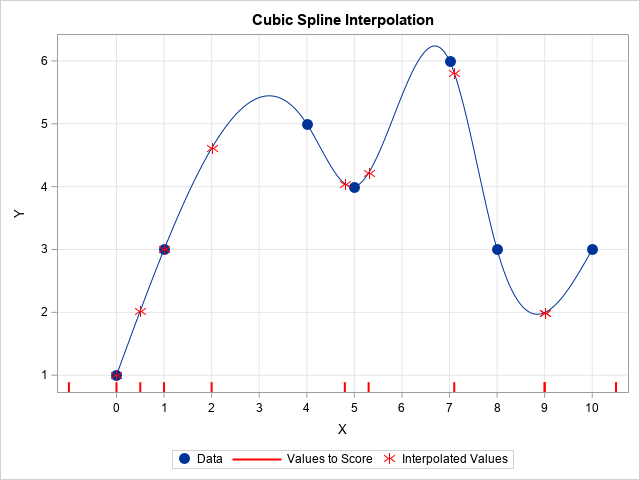

### Similarities between Cubic Hermite Interpolation and Cubic Spline Interpolation

Both promise to generate an interpolation without sudden turns in critical data points

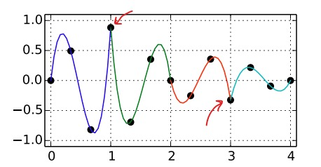

### What makes them different?

Cubic Hermite Interpolation relies on pre-given values of the first derivative (the slope) in the known data points

[figure not shown]

What's the problem with this?

We might not always have access to these derivative values!

This is where Cubic Spline Interpolation comes into play

### 1.2 Goal

Achieve a smooth, stable, piecewise interpolation without knowing the values of the derivatives in advance

Solution? Add conditions for the transition in critical turning points

The function bends in critical points because its derivative is not continuous in those points

Definition of Continuity in $x_1$ (where $f(x_1) = y_1$ is the data point ($x_1$,$y_1$) and $f$ is a cubic polynomial):

$$\lim_{x \to x_1} f(x) = f(x_1)$$

This is equivalent to $$\lim_{x \nearrow x_1} f(x) = \lim_{x \searrow x_1} f(x)$$

Which is the same as

$$\ f_0^\prime(x_1) = f_1^\prime(x_1)$$

Left and right derivatives in point $x_1$ must be equal in order for the derivative to be continuous.

General case is $$\ f_i^\prime(x_{i+1}) = f_{i+1}^\prime(x_{i+1})$$

### 1.3 Smooth Transition Conditions

As before, we require that the polynomial pieces give us the right values in the respective $x_i$ data points

The polynomial function $f_i$ should interpolate our end function in the interval $[x_i,x_{i+1}]$, which includes the values $y_i$ and $y_{i+1}$

Equal value conditions: $$f_i(x_i) = (1,x_i,x_i^2,x_i^3)c_i = y_i$$ $$f_i(x_{i+1}) = (1,x_{i+1},x_{i+1}^2,x_{i+1}^3)c_i = y_{i+1}$$

Where $c_i$ is the coefficient vector of polynomial $f_i$

As mentioned before, we also want to have equal left and right derivatives for all points $x_i$ except for the first and last one.

Condition for left and right derivative equality: $$f_{i-1}^\prime(x_i) = (0,1,2x_i,3x_i^2)c_{i-1} = (0,1,2x_i,3x_i^2)c_i = f_i^\prime(x_i)$$

One freedom degree left, so we add condition for the second derivative to be equal on the left and on the right:

$$f_{i-1}''(x_i) = (0,0,2,6x_i)c_{i-1} = (0,0,2,6x_i)c_i = f_i''(x_i)$$

Observation: Our polynomials now depend on eachother

### 2. Transition Conditions as a system of linear equations

Now that the base polynomials all depend on eachother, we must solve a large system of equations for all of the polynomials

We have the following polynomials and their first and second derivatives:

$$ f_i(x_i) = a_i + b_i x_i + c_i x_i^2 + d_i x_i^3 \\ f_i'(x_i) = b_i + 2c_i x_i + 3d_i x_i^2 \\ f_i''(x_i) = 2c_i + 6d_i x_i \\ $$

Since we prefer to have equations with a constant on the right side, we change

$$f_{i-1}^\prime(x_i) = f_i^\prime(x_i)$$

to $$f_{i-1}^\prime(x_i) - f_i^\prime(x_i) = 0$$

If we substitute with the previous polynomials we get: $$b_{i-1} + 2c_{i-1} x_i + 3d_{i-1} x_i^2 - b_i - 2c_i x_i - 3d_i x_i^2 = 0$$

Analogously for the second derivatives:

$$f_{i-1}''(x_i) = f_i''(x_i)$$

to $$f_{i-1}''(x_i) - f_i''(x_i) = 0$$

Substitution:

$$2c_{i-1} + 6d_{i-1} x_i - 2c_i - 6d_i x_i = 0$$

The vector we have to solve for is the coefficient vector: $$\vec{c} = (a_0, b_0, c_0, d_0, a_1, b_1, c_1, d_1, a_2 ,..., d_{n-1})^T$$

This vector contains the coefficients for n-1 cubic polynomials, so it has a length of $4(n-1)$

The result vector (which contains the constants on the right side of the equations) is the following: $$\vec{b} = (y_0, y_1, \ 0, \ 0, y_1, y_2, \ 0, \ 0, y_2, y_3 ... , y_{n-2}, y_{n-1})^T$$

### Putting everything together in one big system of linear equations:

[figure not shown]

If you look closely, you will notice this SLE only has $4n-6$ equations in it.

Since we need $4(n-1)$ equations to solve it determinately, we have a freedom degree of 2 left to play around with edge conditions

### Theme comprehension questions:

- Why do we use cubic polynomials to interpolate our data points?
- Why is cubic spline interpolation preferred over higher degree polynomial interpolation?